# Returning Users - Channel

Shyni David

11/25/2019

Loading packages

```r
library(openxlsx)
library(tidyverse)
```

```r
library(readxl)
library(ggplot2)
```

Import Data Channel- Returning Users

```r
DA <-  read_excel("~/Desktop/Job related/Surefoot/Surefoot 2/Surefoot- GA/Analysis - 2/test and control dates/Returned Users+Channel/Returning Users-Channel.xlsx", sheet = 2)
```

Data wrangling

```r
DA_01 <- DA

colnames(DA_01)[colnames(DA_01)=="Default Channel Grouping"] <- "Channel"
colnames(DA_01)[colnames(DA_01)=="Date Range"] <- "Date_Range"
colnames(DA_01)[colnames(DA_01)=="New Users"] <- "New_Users"
colnames(DA_01)[colnames(DA_01)=="Bounce Rate"] <- "Bounce_Rate"


DA_02 <- DA_01 %>% filter(!is.na(Channel))

DA_03 <- DA_02 %>% mutate(test_categ = ifelse(Date_Range == "Oct 18, 2019 - Oct 31, 2019", "test-Oct 18,2019 - Oct 31,2019", "control-Oct 4,2019 - Oct 17,2019"))

DA_m <- DA_03 %>% filter(Date_Range == "Oct 18, 2019 - Oct 31, 2019")
```

Visualization Channel-Returning Users count

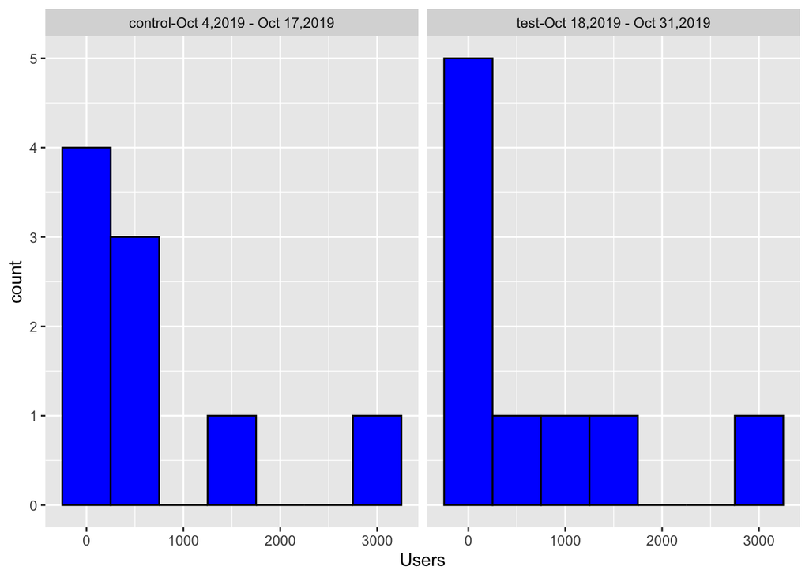

```r
DA_03 %>% filter(Users > 0 ) %>% ggplot() + geom_histogram(aes(Users), binwidth = 500, fill = "blue",col = "black") + facet_wrap(~test_categ)
```

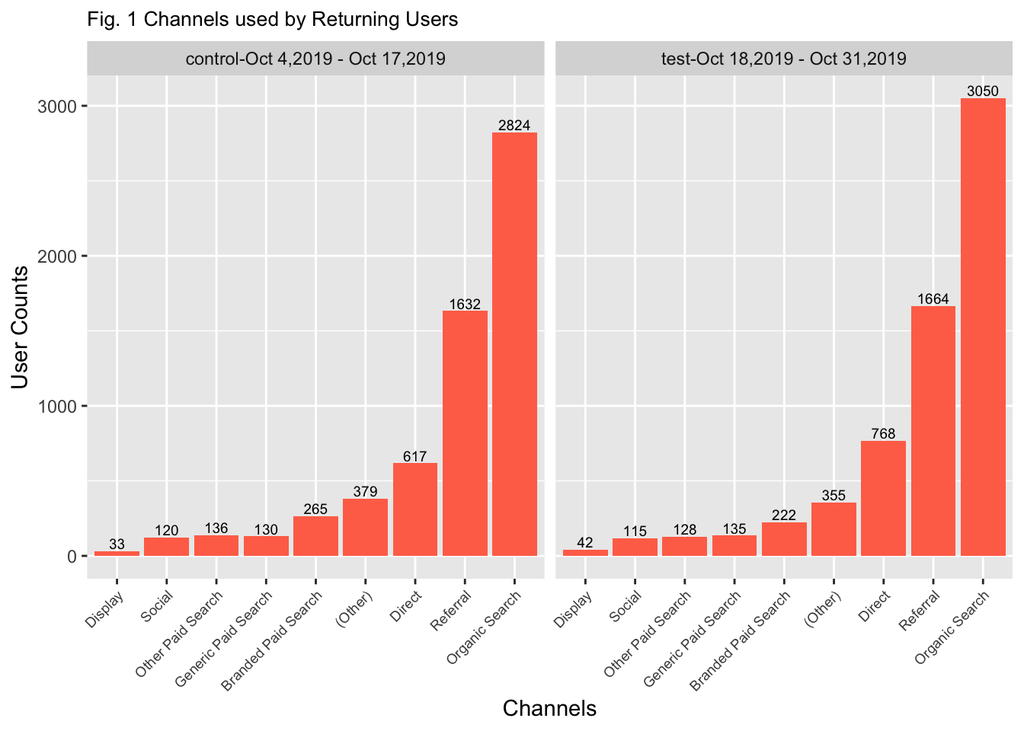

```r
DA_03 %>%
  group_by(Channel) %>%
  ggplot(aes(reorder(x =  as.factor(Channel), Users),  y=Users)) + geom_bar(stat = 'identity', fill = "coral1") + ggtitle("Fig. 1 Channels used by Returning Users") + geom_text(aes(label=Users), size = 2.5, position=position_dodge(width=0.2), vjust=-0.25) + theme(plot.title = element_text(size =10),axis.text.x = element_text(size =7,angle = 45, hjust = 1))  + xlab("Channels") +ylab("User Counts")+ facet_wrap(~test_categ)
```

Channel-Returning Users-Sessions

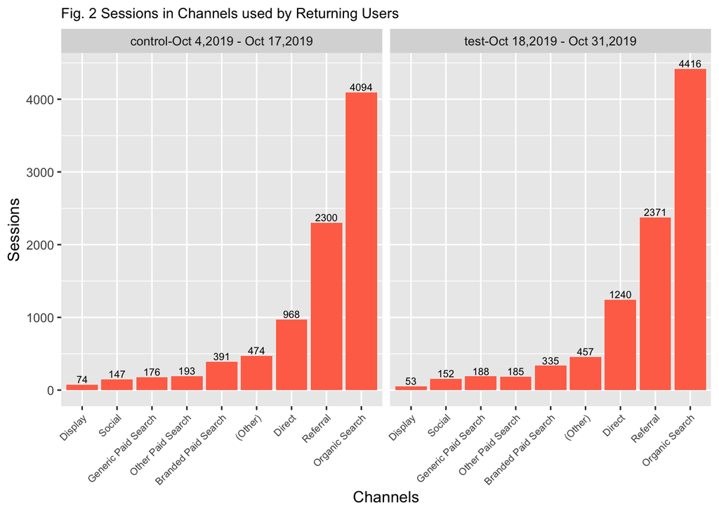

```r
DA_03 %>%
  group_by(Channel) %>%
  ggplot(aes(reorder(x =  as.factor(Channel), Sessions),  y=Sessions)) + geom_bar(stat = 'identity', fill = "coral1") + ggtitle("Fig. 2 Sessions in Channels used by Returning Users") + geom_text(aes(label=Sessions), size = 2.5, position=position_dodge(width=0.2), vjust=-0.25) + theme(plot.title = element_text(size =10),axis.text.x = element_text(size =7,angle = 45, hjust = 1))  + xlab("Channels") +ylab("Sessions")+ facet_wrap(~test_categ)
```

Channel-Returning Users-Bounce Rate

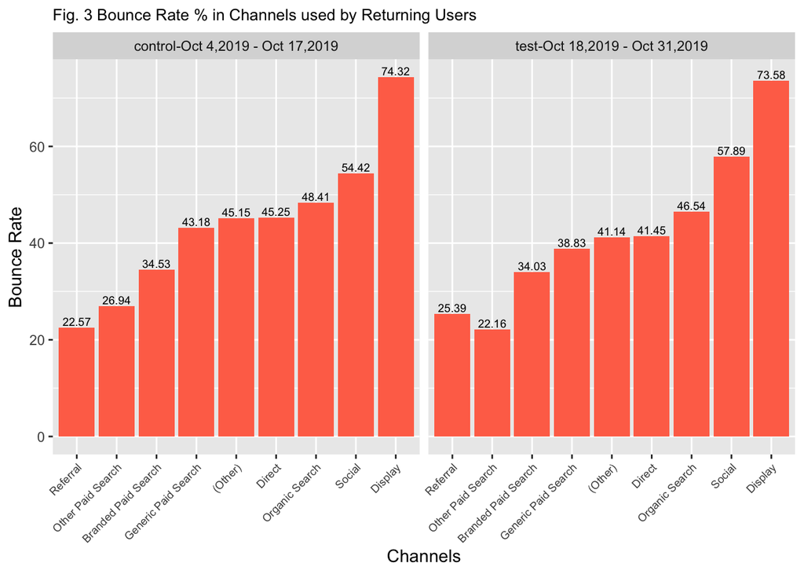

```r
DA_03_01 <- DA_03 %>% mutate(Bounce_Rt = round(Bounce_Rate*100,2))
DA_03_01 %>%
  group_by(Channel) %>%
  ggplot(aes(reorder(x =  as.factor(Channel), Bounce_Rt),  y=Bounce_Rt)) + geom_bar(stat = 'identity', fill = "coral1") + ggtitle("Fig. 3 Bounce Rate % in Channels used by Returning Users") + geom_text(aes(label=Bounce_Rt), size = 2.5, position=position_dodge(width=0.2), vjust=-0.25) + theme(plot.title = element_text(size =10),axis.text.x = element_text(size =7,angle = 45, hjust = 1))  + xlab("Channels") +ylab("Bounce Rate")+ facet_wrap(~test_categ)
```

Channel-Returning Users-Revenue

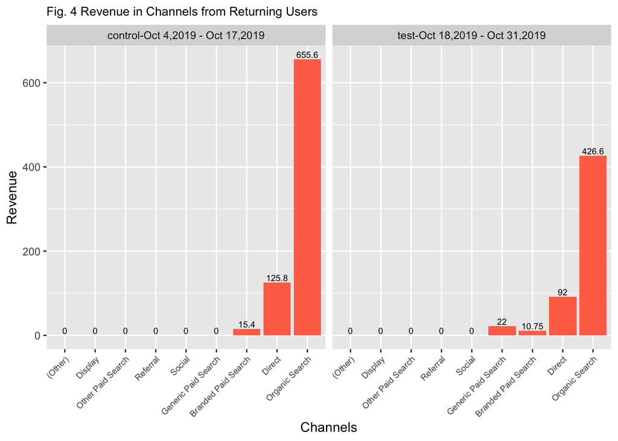

```r
DA_03 %>%
  group_by(Channel) %>%
  ggplot(aes(reorder(x =  as.factor(Channel), Revenue),  y=Revenue)) + geom_bar(stat = 'identity', fill = "coral1") + ggtitle("Fig. 4 Revenue in Channels from Returning Users") + geom_text(aes(label=Revenue), size = 2.5, position=position_dodge(width=0.2), vjust=-0.25) + theme(plot.title = element_text(size =10),axis.text.x = element_text(size =7,angle = 45, hjust = 1))  + xlab("Channels") +ylab("Revenue")+ facet_wrap(~test_categ)
```

Import Data Channel- Returning Users - City

```r
DC <-  read_excel("~/Desktop/Job related/Surefoot/Surefoot 2/Surefoot- GA/Analysis - 2/test and control dates/Returned Users+Channel/channel-cityname.xlsx", sheet = 2)
```

Data wrangling

```r
DC_01 <- DC

colnames(DC_01)[colnames(DC_01)=="Default Channel Grouping"] <- "Channel"
colnames(DC_01)[colnames(DC_01)=="Date Range"] <- "Date_Range"
colnames(DC_01)[colnames(DC_01)=="New Users"] <- "New_Users"
colnames(DC_01)[colnames(DC_01)=="Bounce Rate"] <- "Bounce_Rate"


DC_02 <- DC_01 %>% filter(!is.na(Channel))

DC_03 <- DC_02 %>% mutate(test_categ = ifelse(Date_Range == "Oct 18, 2019 - Oct 31, 2019", "test-Oct 18,2019 - Oct 31,2019", "control-Oct 4,2019 - Oct 17,2019"))

DC_m <- DC_03 %>% filter(Date_Range == "Oct 18, 2019 - Oct 31, 2019")
```

Channel-Returning Users- City

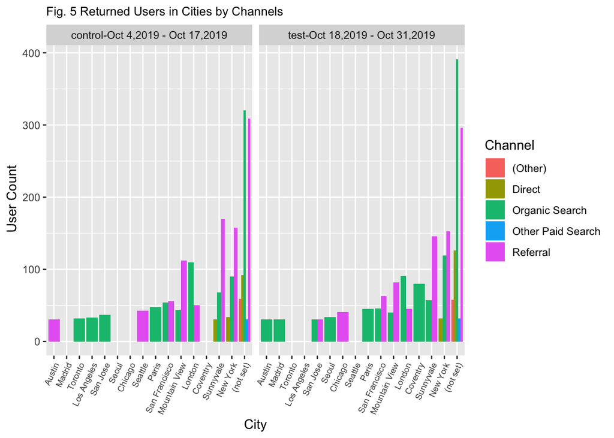

```r
DC_03  %>%
  group_by( City, Channel, test_categ) %>% filter(Users > 30) %>%
  ggplot(aes(reorder(x = as.factor(City), Users ), y = Users, fill = Channel )) + geom_bar(stat = 'identity' , position = "dodge") + ggtitle("Fig. 5 Returned Users in Cities by Channels ")  + theme(plot.title = element_text(size =10),axis.text.x = element_text(size =7,angle = 65, hjust = 1) )  +  xlab("City") + ylab(" User Count") + facet_wrap(~test_categ)
```

Import Data Channel- Returning Users - Country

```r
DCo <-  read_excel("~/Desktop/Job related/Surefoot/Surefoot 2/Surefoot- GA/Analysis - 2/test and control dates/Returned Users+Channel/channel-country.xlsx", sheet = 2)
```

Data wrangling

```r
DC_01 <- DCo

colnames(DC_01)[colnames(DC_01)=="Default Channel Grouping"] <- "Channel"
colnames(DC_01)[colnames(DC_01)=="Date Range"] <- "Date_Range"
colnames(DC_01)[colnames(DC_01)=="New Users"] <- "New_Users"
colnames(DC_01)[colnames(DC_01)=="Bounce Rate"] <- "Bounce_Rate"


DC_02 <- DC_01 %>% filter(!is.na(Channel))

DC_03 <- DC_02 %>% mutate(test_categ = ifelse(Date_Range == "Oct 18, 2019 - Oct 31, 2019", "test-Oct 18,2019 - Oct 31,2019", "control-Oct 4,2019 - Oct 17,2019"))

DCo_m <- DC_03 %>% filter(Date_Range == "Oct 18, 2019 - Oct 31, 2019")
```

Channel-Returning Users- country

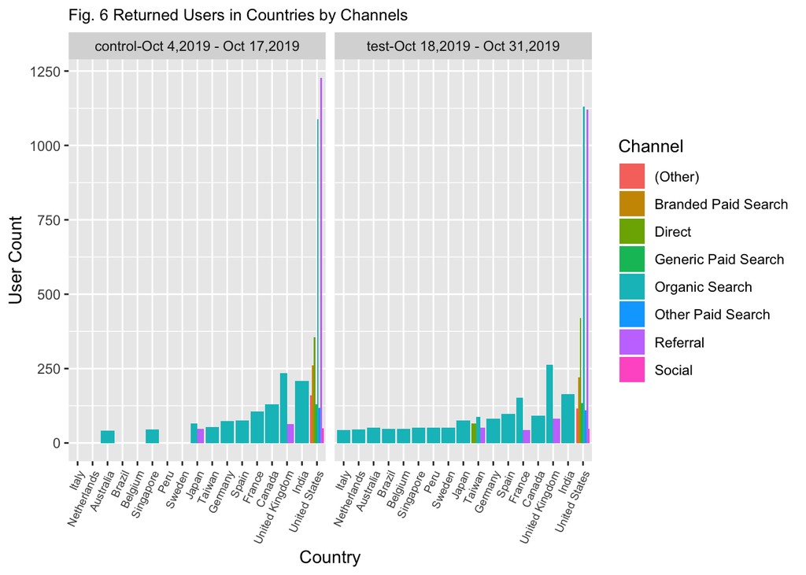

```r
DC_03  %>%
  group_by( Country, Channel, test_categ) %>% filter(Users > 40) %>%
  ggplot(aes(reorder(x = as.factor(Country), Users  ), y = Users, fill = Channel )) + geom_bar(stat = 'identity' , position = "dodge") + ggtitle("Fig. 6 Returned Users in Countries by Channels ")  + theme(plot.title = element_text(size =10),axis.text.x = element_text(size =7,angle = 65, hjust = 1) )  +  xlab("Country") + ylab("User Count") + facet_wrap(~test_categ)
```

Import Data Channel- Returning Users - Hour

```r
DH <-  read_excel("~/Desktop/Job related/Surefoot/Surefoot 2/Surefoot- GA/Analysis - 2/test and control dates/Returned Users+Channel/Channel-Returning Users-Hour of the day.xlsx", sheet = 2)
```

Data wrangling

```r
DC_01 <- DH

colnames(DC_01)[colnames(DC_01)=="Default Channel Grouping"] <- "Channel"
colnames(DC_01)[colnames(DC_01)=="Date Range"] <- "Date_Range"
colnames(DC_01)[colnames(DC_01)=="New Users"] <- "New_Users"
colnames(DC_01)[colnames(DC_01)=="Bounce Rate"] <- "Bounce_Rate"


DC_02 <- DC_01 %>% filter(!is.na(Channel))

DC_03 <- DC_02 %>% mutate(test_categ = ifelse(Date_Range == "Oct 18, 2019 - Oct 31, 2019", "test-Oct 18,2019 - Oct 31,2019", "control-Oct 4,2019 - Oct 17,2019"))

DH_m <- DC_03 %>% filter(Date_Range == "Oct 18, 2019 - Oct 31, 2019")
```

Channel-Returning Users- Hour

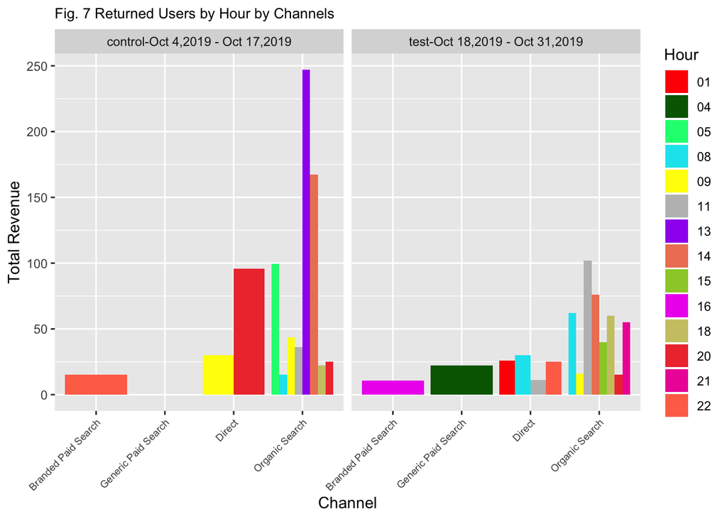

```r
DC_04 <- DC_03 %>% select(Channel,  Hour, Revenue, test_categ)
DC_05 <- unique(DC_04)

DC_06 <- DC_05 %>% group_by(Channel, Hour, test_categ) %>% mutate(TotRev = sum(Revenue)) %>% select(Channel, Hour, TotRev, test_categ)
DC_07 <- unique(DC_06)


DC_07$Hour<- as.factor(DC_07$Hour)
DC_07  %>% filter(TotRev > 0) %>%
ggplot(aes(reorder(x=Channel, TotRev), y=TotRev, fill=Hour)) +
  geom_bar(stat="identity", position = "dodge")  + theme(plot.title = element_text(size =10),axis.text.x = element_text(size =7,angle = 45, hjust = 1) ) + ggtitle("Fig. 7 Returned Users by Hour by Channels ") +xlab("Channel") + ylab("Total Revenue") +  scale_fill_manual(values=c("red", "darkgreen", "springgreen1", "turquoise2", "yellow", "grey", "purple", "salmon2", "olivedrab3", "magenta2", "khaki3", "brown2", "maroon2", "coral1", "grey45", "goldenrod1", "slategray3","tan4", "orchid3", "hotpink4", "black", "brown4", "lightpink2" )) + guides(colour = guide_legend(override.aes = list(size=3, alpha = 1))) + scale_shape_manual(values=c(3:9)) + facet_wrap(~test_categ)
```

Import Data Channel- Returning Users - Age

```r
DAge <-  read_excel("~/Desktop/Job related/Surefoot/Surefoot 2/Surefoot- GA/Analysis - 2/test and control dates/Returned Users+Channel/Channel+Age.xlsx", sheet = 2)
```

Data wrangling

```r
DC_01 <- DAge

colnames(DC_01)[colnames(DC_01)=="Default Channel Grouping"] <- "Channel"
colnames(DC_01)[colnames(DC_01)=="Date Range"] <- "Date_Range"
colnames(DC_01)[colnames(DC_01)=="New Users"] <- "New_Users"
colnames(DC_01)[colnames(DC_01)=="Bounce Rate"] <- "Bounce_Rate"


DC_02 <- DC_01 %>% filter(!is.na(Channel))

DC_03 <- DC_02 %>% mutate(test_categ = ifelse(Date_Range == "Oct 18, 2019 - Oct 31, 2019", "test-Oct 18,2019 - Oct 31,2019", "control-Oct 4,2019 - Oct 17,2019"))

DAge_m <- DC_03 %>% filter(Date_Range == "Oct 18, 2019 - Oct 31, 2019")
```

Channel-Returning Users- Age

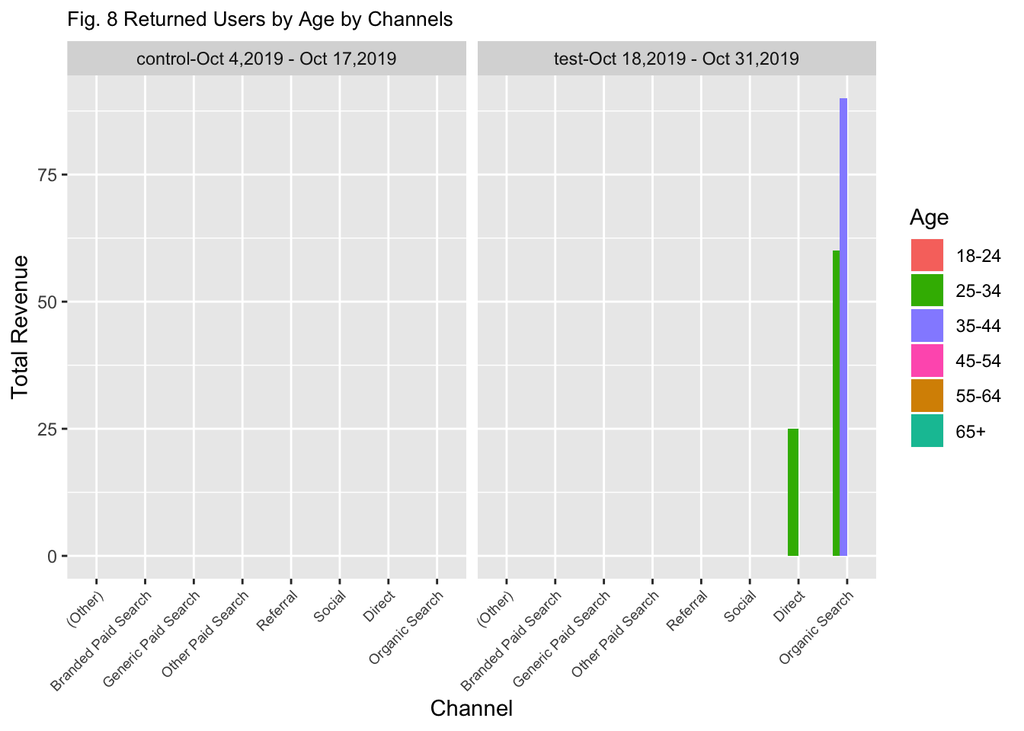

```r
DA_20 <- DC_03 %>% select( Age, Channel, Revenue, test_categ)
DA_21 <- unique(DA_20)



DA_24 <- DA_21 %>% select(Age, Channel, Revenue, test_categ) %>% group_by(Channel, Age, test_categ) %>% mutate(  TotRev = sum(Revenue)) %>% select(Channel, Age, TotRev, test_categ)
DA_25 <- unique(DA_24)


DA_25$Age<- as.factor(DA_25$Age)
DA_25 %>%
ggplot(aes(reorder(x=Channel, TotRev), y=TotRev, fill=Age)) +
  geom_bar(stat="identity", position = "dodge")  + theme(plot.title = element_text(size =10),axis.text.x = element_text(size =7,angle = 45, hjust = 1) ) + ggtitle("Fig. 8 Returned Users by Age by Channels ")+xlab("Channel") + ylab("Total Revenue") +  scale_fill_manual(values=c("#F8766D", "#39B600",  "#9590FF", "#FF62BC", "#D89000", "#00C1A3", "#A3A500", "#EA8331", "#00BFCD", "#00B4F0", "#00BFC4" )) + guides(colour = guide_legend(override.aes = list(size=3, alpha = 1))) + scale_shape_manual(values=c(3:9)) + facet_wrap(~test_categ)
```

Import Data Channel- Returning Users - Gender

```r
DG <-  read_excel("~/Desktop/Job related/Surefoot/Surefoot 2/Surefoot- GA/Analysis - 2/test and control dates/Returned Users+Channel/Returning users+gender+channel.xlsx", sheet = 2)
```

Data wrangling

```r
DC_01 <- DG

colnames(DC_01)[colnames(DC_01)=="Default Channel Grouping"] <- "Channel"
colnames(DC_01)[colnames(DC_01)=="Date Range"] <- "Date_Range"
colnames(DC_01)[colnames(DC_01)=="New Users"] <- "New_Users"
colnames(DC_01)[colnames(DC_01)=="Bounce Rate"] <- "Bounce_Rate"


DC_02 <- DC_01 %>% filter(!is.na(Channel))

DC_03 <- DC_02 %>% mutate(test_categ = ifelse(Date_Range == "Oct 18, 2019 - Oct 31, 2019", "test-Oct 18,2019 - Oct 31,2019", "control-Oct 4,2019 - Oct 17,2019"))


DG_m <- DC_03 %>% filter(Date_Range == "Oct 18, 2019 - Oct 31, 2019")
```

Channel- Returning Users - Gender

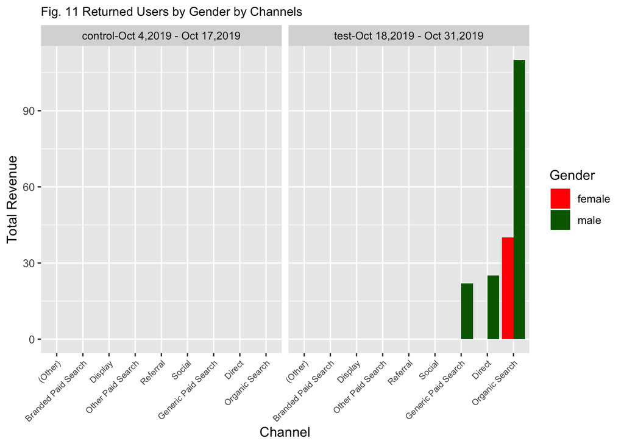

```r
DA_20 <- DC_03 %>% select(Channel, Gender, Revenue, test_categ)
DA_23 <- unique(DA_20)

DA_24 <- DA_23 %>% group_by(Channel, Gender, test_categ) %>% mutate(TotRev = sum(Revenue)) %>% select(Channel, Gender, TotRev, test_categ)
DA_25 <- unique(DA_24)

DA_25$Gender<- as.factor(DA_25$Gender)
DA_25 %>%
ggplot(aes(reorder(x=Channel, TotRev), y=TotRev, fill=Gender)) +
  geom_bar(stat="identity", position = "dodge")  + theme(plot.title = element_text(size =10),axis.text.x = element_text(size =7,angle = 45, hjust = 1) ) + ggtitle("Fig. 11 Returned Users by Gender by Channels ") +xlab("Channel") + ylab("Total Revenue") +  scale_fill_manual(values=c("red", "darkgreen", "springgreen1", "turquoise2", "yellow", "grey", "purple", "salmon2", "olivedrab3", "magenta2", "khaki3", "brown2", "maroon2", "coral1", "grey45", "goldenrod1", "slategray3","tan4", "orchid3", "hotpink4", "black", "brown4", "lightpink2" )) + guides(colour = guide_legend(override.aes = list(size=3, alpha = 1))) + scale_shape_manual(values=c(3:9))  + facet_wrap(~test_categ)
```

Import Data Channel- Returning Users - Device

```r
DD <-  read_excel("~/Desktop/Job related/Surefoot/Surefoot 2/Surefoot- GA/Analysis - 2/test and control dates/Returned Users+Channel/device+channel.xlsx", sheet = 2)
```

Data wrangling

```r
DC_01 <- DD
 names(DD)
```

```
##  [1] "Default Channel Grouping"  "Device Category"
##  [3] "Date Range"                "Segment"
##  [5] "Users"                     "New Users"
##  [7] "Sessions"                  "Bounce Rate"
##  [9] "Pages / Session"           "Avg. Session Duration"
## [11] "Ecommerce Conversion Rate" "Transactions"
## [13] "Revenue"
```

```r
colnames(DC_01)[colnames(DC_01)=="Default Channel Grouping"] <- "Channel"
colnames(DC_01)[colnames(DC_01)=="Device Category"] <- "Device"
colnames(DC_01)[colnames(DC_01)=="Date Range"] <- "Date_Range"
colnames(DC_01)[colnames(DC_01)=="New Users"] <- "New_Users"
colnames(DC_01)[colnames(DC_01)=="Bounce Rate"] <- "Bounce_Rate"


DC_02 <- DC_01 %>% filter(!is.na(Channel))

DC_03 <- DC_02 %>% mutate(test_categ = ifelse(Date_Range == "Oct 18, 2019 - Oct 31, 2019", "test-Oct 18,2019 - Oct 31,2019", "control-Oct 4,2019 - Oct 17,2019"))

DD_m <- DC_03 %>% filter(Date_Range == "Oct 18, 2019 - Oct 31, 2019")
```

Visualization

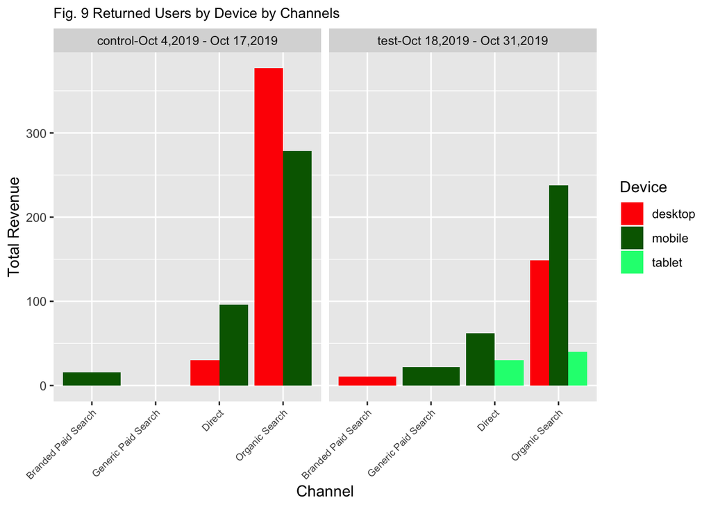

```r
DA_20 <- DC_03  %>% select(Channel, Device, Revenue, test_categ)
DA_23 <- unique(DA_20)

DA_24 <- DA_23 %>% group_by(Channel, Device, test_categ) %>% mutate(TotRev = sum(Revenue)) %>% select(Channel, Device, TotRev, test_categ)
DA_25 <- unique(DA_24)

DA_25$Device<- as.factor(DA_25$Device)
DA_25 %>% filter(TotRev > 0) %>%
ggplot(aes(reorder(x=Channel, TotRev), y=TotRev, fill=Device)) +
  geom_bar(stat="identity", position = "dodge")  + theme(plot.title = element_text(size =10),axis.text.x = element_text(size =7,angle = 45, hjust = 1) ) + ggtitle("Fig. 9 Returned Users by Device by Channels ") +xlab("Channel") + ylab("Total Revenue") +  scale_fill_manual(values=c("red", "darkgreen", "springgreen1", "turquoise2", "yellow", "grey", "purple", "salmon2", "olivedrab3", "magenta2", "khaki3", "brown2", "maroon2", "coral1", "grey45", "goldenrod1", "slategray3","tan4", "orchid3", "hotpink4", "black", "brown4", "lightpink2" )) + guides(colour = guide_legend(override.aes = list(size=3, alpha = 1))) + scale_shape_manual(values=c(3:9)) + facet_wrap(~test_categ)
```

Import Data Channel- Returning Users - Behaviour(Page Views)

```r
DP <-  read_excel("~/Desktop/Job related/Surefoot/Surefoot 2/Surefoot- GA/Analysis - 2/test and control dates/Returned Users+Channel/Behaviour+Channel.xlsx", sheet = 2)
```

Data wrangling

```r
DC_01 <- DP
colnames(DC_01)[colnames(DC_01)=="Default Channel Grouping"] <- "Channel"
colnames(DC_01)[colnames(DC_01)=="Date Range"] <- "Date_Range"
colnames(DC_01)[colnames(DC_01)=="New Users"] <- "New_Users"
colnames(DC_01)[colnames(DC_01)=="Bounce Rate"] <- "Bounce_Rate"


DC_02 <- DC_01 %>% filter(!is.na(Channel))

DC_03 <- DC_02 %>% mutate(test_categ = ifelse(Date_Range == "Oct 18, 2019 - Oct 31, 2019", "test-Oct 18,2019 - Oct 31,2019", "control-Oct 4,2019 - Oct 17,2019"))

DP_m <- DC_03 %>% filter(Date_Range == "Oct 18, 2019 - Oct 31, 2019")
```

Visualization

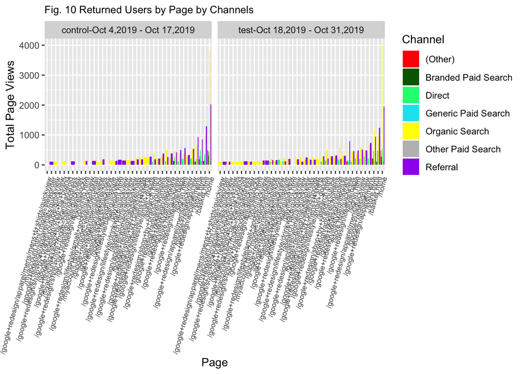

```r
DA_20 <- DC_03  %>% select(Channel, Page, Pageviews, test_categ)
DA_23 <- unique(DA_20)

DA_24 <- DA_23 %>% group_by(Channel, Page, test_categ) %>% mutate(TotPV = sum(Pageviews)) %>% select(Channel, Page, TotPV, test_categ)
DA_25 <- unique(DA_24)

DA_25$Channel<- as.factor(DA_25$Channel)
DA_25 %>% filter(TotPV > 100) %>%
ggplot(aes(reorder(x=Page, TotPV), y=TotPV, fill=Channel)) +
  geom_bar(stat="identity", position = "dodge")  + theme(plot.title = element_text(size =10),axis.text.x = element_text(size =7,angle = 75, hjust = 1) ) + ggtitle("Fig. 10 Returned Users by Page by Channels ") +xlab("Page") + ylab("Total Page Views") +  scale_fill_manual(values=c("red", "darkgreen", "springgreen1", "turquoise2", "yellow", "grey", "purple", "salmon2", "olivedrab3", "magenta2", "khaki3", "brown2", "maroon2", "coral1", "grey45", "goldenrod1", "slategray3","tan4", "orchid3", "hotpink4", "black", "brown4", "lightpink2" )) + guides(colour = guide_legend(override.aes = list(size=3, alpha = 1))) + scale_shape_manual(values=c(3:9)) + facet_wrap(~test_categ)
```

Import Data Channel- Returning Users - Source

```r
DS <-  read_excel("~/Desktop/Job related/Surefoot/Surefoot 2/Surefoot- GA/Analysis - 2/test and control dates/Returned Users+Channel/Source+Channel.xlsx", sheet = 2)
```

Data wrangling

```r
DC_01 <- DS
colnames(DC_01)[colnames(DC_01)=="Default Channel Grouping"] <- "Channel"
colnames(DC_01)[colnames(DC_01)=="Date Range"] <- "Date_Range"
colnames(DC_01)[colnames(DC_01)=="New Users"] <- "New_Users"
colnames(DC_01)[colnames(DC_01)=="Bounce Rate"] <- "Bounce_Rate"


DC_02 <- DC_01 %>% filter(!is.na(Channel))

DC_03 <- DC_02 %>% mutate(test_categ = ifelse(Date_Range == "Oct 18, 2019 - Oct 31, 2019", "test-Oct 18,2019 - Oct 31,2019", "control-Oct 4,2019 - Oct 17,2019"))

DS_m <- DC_03 %>% filter(Date_Range == "Oct 18, 2019 - Oct 31, 2019")
```

Visualization

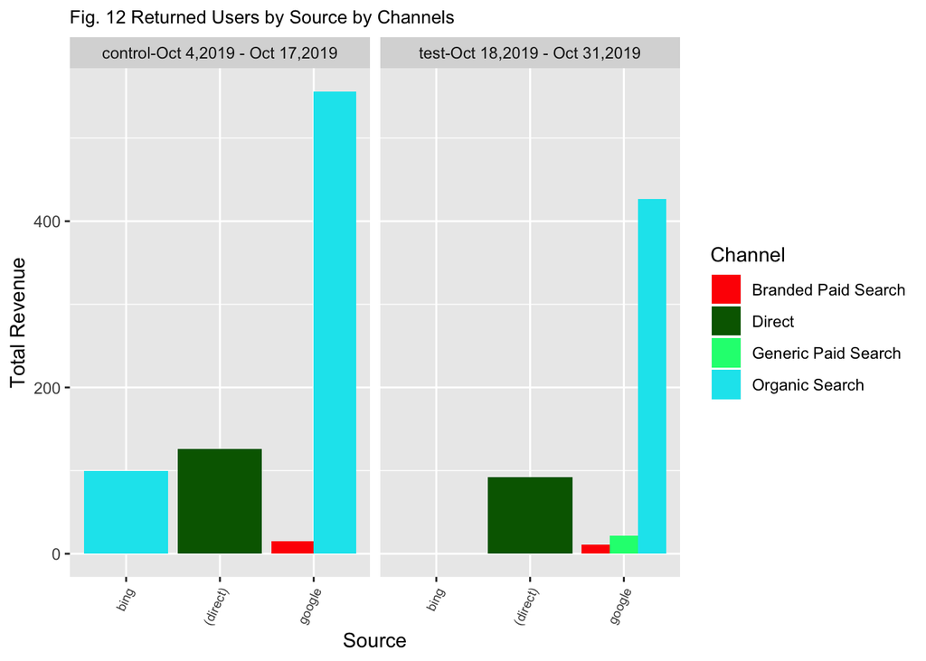

```r
DA_20 <- DC_03  %>% select(Channel, Source, Revenue, test_categ)
DA_23 <- unique(DA_20)

DA_24 <- DA_23 %>% group_by(Channel, Source, test_categ) %>% mutate(TotRv = sum(Revenue)) %>% select(Channel, Source, TotRv, test_categ)
DA_25 <- unique(DA_24)

DA_25$Channel<- as.factor(DA_25$Channel)
DA_25 %>%  filter(TotRv > 0 ) %>%
ggplot(aes(reorder(x=Source, TotRv), y=TotRv, fill=Channel)) +
  geom_bar(stat="identity", position = "dodge")  + theme(plot.title = element_text(size =10),axis.text.x = element_text(size =7,angle = 65, hjust = 1) ) + ggtitle("Fig. 12 Returned Users by Source by Channels ") +xlab("Source") + ylab("Total Revenue") +  scale_fill_manual(values=c("red", "darkgreen", "springgreen1", "turquoise2", "yellow", "grey", "purple", "salmon2", "olivedrab3", "magenta2", "khaki3", "brown2", "maroon2", "coral1", "grey45", "goldenrod1", "slategray3","tan4", "orchid3", "hotpink4", "black", "brown4", "lightpink2" )) + guides(colour = guide_legend(override.aes = list(size=3, alpha = 1))) + scale_shape_manual(values=c(3:9)) + facet_wrap(~test_categ)
```

Import Data Channel- Returning Users - Ad content

```r
DAd <-  read_excel("~/Desktop/Job related/Surefoot/Surefoot 2/Surefoot- GA/Analysis - 2/test and control dates/Returned Users+Channel/Channel+ad-content.xlsx", sheet = 2)
```

Data wrangling

```r
DC_01 <- DAd

colnames(DC_01)[colnames(DC_01)=="Ad Content"] <- "Ad_Content"
colnames(DC_01)[colnames(DC_01)=="Default Channel Grouping"] <- "Channel"
colnames(DC_01)[colnames(DC_01)=="Date Range"] <- "Date_Range"
colnames(DC_01)[colnames(DC_01)=="New Users"] <- "New_Users"
colnames(DC_01)[colnames(DC_01)=="Bounce Rate"] <- "Bounce_Rate"


DC_02 <- DC_01 %>% filter(!is.na(Channel))

DC_03 <- DC_02 %>% mutate(test_categ = ifelse(Date_Range == "Oct 18, 2019 - Oct 31, 2019", "test-Oct 18,2019 - Oct 31,2019", "control-Oct 4,2019 - Oct 17,2019"))

DAd_m <- DC_03 %>% filter(Date_Range == "Oct 18, 2019 - Oct 31, 2019")
```

Visualization

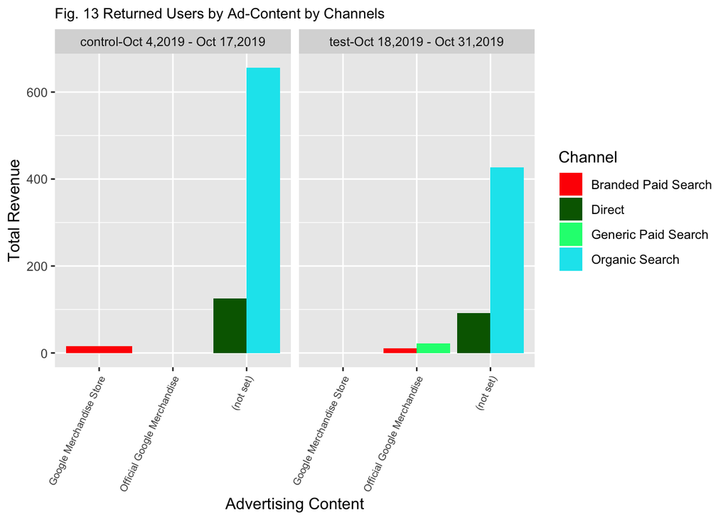

```r
DA_20 <- DC_03  %>% select(Channel, Ad_Content , Revenue, test_categ)
DA_23 <- unique(DA_20)

DA_24 <- DA_23 %>% group_by(Channel, Ad_Content, test_categ) %>% mutate(TotRv = sum(Revenue)) %>% select(Channel, Ad_Content, TotRv, test_categ)
DA_25 <- unique(DA_24)

DA_25$Channel<- as.factor(DA_25$Channel)
DA_25 %>%  filter(TotRv > 0 ) %>%
ggplot(aes(reorder(x=Ad_Content, TotRv), y=TotRv, fill=Channel)) +
  geom_bar(stat="identity", position = "dodge")  + theme(plot.title = element_text(size =10),axis.text.x = element_text(size =7,angle = 65, hjust = 1) ) + ggtitle("Fig. 13 Returned Users by Ad-Content by Channels ") +xlab("Advertising Content") + ylab("Total Revenue") +  scale_fill_manual(values=c("red", "darkgreen", "springgreen1", "turquoise2", "yellow", "grey", "purple", "salmon2", "olivedrab3", "magenta2", "khaki3", "brown2", "maroon2", "coral1", "grey45", "goldenrod1", "slategray3","tan4", "orchid3", "hotpink4", "black", "brown4", "lightpink2" )) + guides(colour = guide_legend(override.aes = list(size=3, alpha = 1))) + scale_shape_manual(values=c(3:9)) + facet_wrap(~test_categ)
```

Import Data Channel- Returning Users - Goal1 - Purchases Completed

```r
DA_Goal1 <-  read_excel("~/Desktop/Job related/Surefoot/Surefoot 2/Surefoot- GA/Analysis - 2/test and control dates/Returned Users+Channel/Channel+Goal1.xlsx", sheet = 2)
```

Data wrangling

```r
DC_01 <- DA_Goal1

colnames(DC_01)[colnames(DC_01)=="Purchase Completed (Goal 1 Completions)"] <- "Purchases_completed"
colnames(DC_01)[colnames(DC_01)=="Default Channel Grouping"] <- "Channel"
colnames(DC_01)[colnames(DC_01)=="Date Range"] <- "Date_Range"
colnames(DC_01)[colnames(DC_01)=="New Users"] <- "New_Users"
colnames(DC_01)[colnames(DC_01)=="Bounce Rate"] <- "Bounce_Rate"


DC_02 <- DC_01 %>% filter(!is.na(Channel))

DC_03 <- DC_02 %>% mutate(test_categ = ifelse(Date_Range == "Oct 18, 2019 - Oct 31, 2019", "test-Oct 18,2019 - Oct 31,2019", "control-Oct 4,2019 - Oct 17,2019"))

DG1_m <- DC_03 %>% filter(Date_Range == "Oct 18, 2019 - Oct 31, 2019")
```

Visualizations

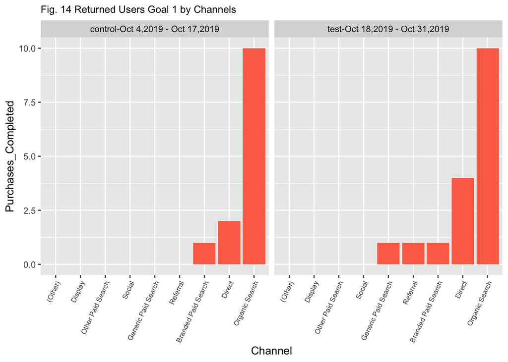

```r
DC_03 %>%
ggplot(aes(reorder(x=Channel, Purchases_completed), y=Purchases_completed )) +
  geom_bar(stat="identity",fill = "coral1")  + theme(plot.title = element_text(size =10),axis.text.x = element_text(size =7,angle = 65, hjust = 1) ) + ggtitle("Fig. 14 Returned Users Goal 1 by Channels ") +xlab("Channel") + ylab("Purchases_Completed")  + facet_wrap(~test_categ)
```

Import Data Channel- Returning Users - Goal2 - Engaged Users

```r
DA_Goal2 <-  read_excel("~/Desktop/Job related/Surefoot/Surefoot 2/Surefoot- GA/Analysis - 2/test and control dates/Returned Users+Channel/Channel+Goal2.xlsx", sheet = 2)
```

Data wrangling

```r
DC_01 <- DA_Goal2

colnames(DC_01)[colnames(DC_01)=="Engaged Users (Goal 2 Completions)"] <- "Engaged_Users"
colnames(DC_01)[colnames(DC_01)=="Default Channel Grouping"] <- "Channel"
colnames(DC_01)[colnames(DC_01)=="Date Range"] <- "Date_Range"
colnames(DC_01)[colnames(DC_01)=="New Users"] <- "New_Users"
colnames(DC_01)[colnames(DC_01)=="Bounce Rate"] <- "Bounce_Rate"


DC_02 <- DC_01 %>% filter(!is.na(Channel))

DC_03 <- DC_02 %>% mutate(test_categ = ifelse(Date_Range == "Oct 18, 2019 - Oct 31, 2019", "test-Oct 18,2019 - Oct 31,2019", "control-Oct 4,2019 - Oct 17,2019"))

DG2_m <- DC_03 %>% filter(Date_Range == "Oct 18, 2019 - Oct 31, 2019")
```

Visualizations

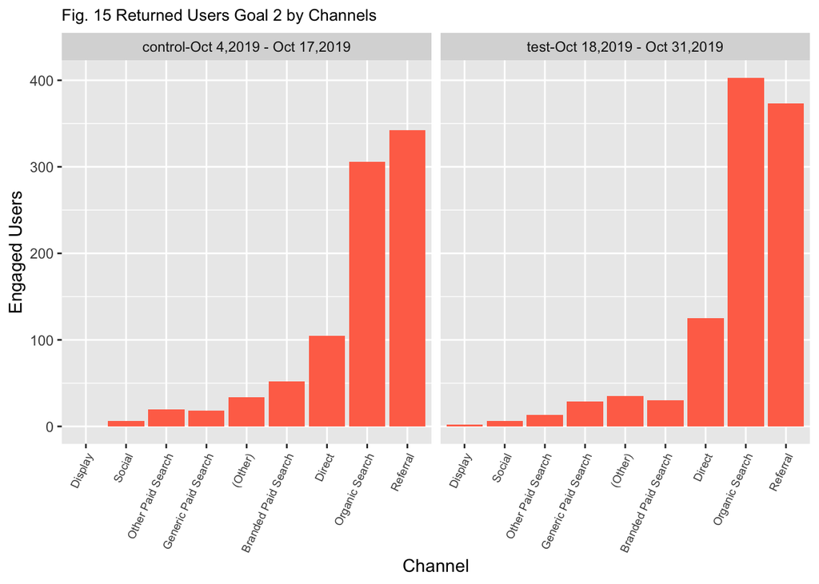

```r
DC_03 %>%
ggplot(aes(reorder(x=Channel, Engaged_Users), y=Engaged_Users )) +
  geom_bar(stat="identity",fill = "coral1")  + theme(plot.title = element_text(size =10),axis.text.x = element_text(size =7,angle = 65, hjust = 1) ) + ggtitle("Fig. 15 Returned Users Goal 2 by Channels ") +xlab("Channel") + ylab("Engaged Users") +  facet_wrap(~test_categ)
```

Import Data Channel- Returning Users - Goal3 - Registrations Completed

```r
DA_Goal3 <-  read_excel("~/Desktop/Job related/Surefoot/Surefoot 2/Surefoot- GA/Analysis - 2/test and control dates/Returned Users+Channel/Channel+Goal3.xlsx", sheet = 2)
```

Data wrangling

```r
DC_01 <- DA_Goal3

colnames(DC_01)[colnames(DC_01)=="Registrations (Goal 3 Completions)"] <- "Registrations_completed"
colnames(DC_01)[colnames(DC_01)=="Default Channel Grouping"] <- "Channel"
colnames(DC_01)[colnames(DC_01)=="Date Range"] <- "Date_Range"
colnames(DC_01)[colnames(DC_01)=="New Users"] <- "New_Users"
colnames(DC_01)[colnames(DC_01)=="Bounce Rate"] <- "Bounce_Rate"


DC_02 <- DC_01 %>% filter(!is.na(Channel))

DC_03 <- DC_02 %>% mutate(test_categ = ifelse(Date_Range == "Oct 18, 2019 - Oct 31, 2019", "test-Oct 18,2019 - Oct 31,2019", "control-Oct 4,2019 - Oct 17,2019"))

DG3_m <- DC_03 %>% filter(Date_Range == "Oct 18, 2019 - Oct 31, 2019")
```

Visualizations

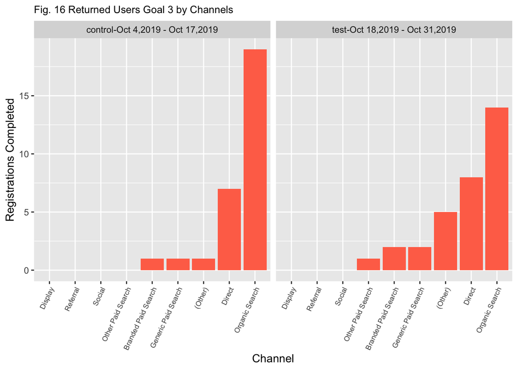

```r
DC_03 %>%
ggplot(aes(reorder(x=Channel, Registrations_completed), y=Registrations_completed)) +
  geom_bar(stat="identity",fill = "coral1")  + theme(plot.title = element_text(size =10),axis.text.x = element_text(size =7,angle = 65, hjust = 1) ) + ggtitle("Fig. 16 Returned Users Goal 3 by Channels ") +xlab("Channel") + ylab("Registrations Completed") +  facet_wrap(~test_categ)
```

Import Data Channel- Returning Users - Goal4 - Entered Checkout

```r
DA_Goal4 <-  read_excel("~/Desktop/Job related/Surefoot/Surefoot 2/Surefoot- GA/Analysis - 2/test and control dates/Returned Users+Channel/Channel+Goal4.xlsx", sheet = 2)
```

Data wrangling

```r
DC_01 <- DA_Goal4

colnames(DC_01)[colnames(DC_01)=="Entered Checkout (Goal 4 Completions)"] <- "Entered_checkout"
colnames(DC_01)[colnames(DC_01)=="Default Channel Grouping"] <- "Channel"
colnames(DC_01)[colnames(DC_01)=="Date Range"] <- "Date_Range"
colnames(DC_01)[colnames(DC_01)=="New Users"] <- "New_Users"
colnames(DC_01)[colnames(DC_01)=="Bounce Rate"] <- "Bounce_Rate"


DC_02 <- DC_01 %>% filter(!is.na(Channel))

DC_03 <- DC_02 %>% mutate(test_categ = ifelse(Date_Range == "Oct 18, 2019 - Oct 31, 2019", "test-Oct 18,2019 - Oct 31,2019", "control-Oct 4,2019 - Oct 17,2019"))

DG4_m <- DC_03 %>% filter(Date_Range == "Oct 18, 2019 - Oct 31, 2019")
```

Visualizations

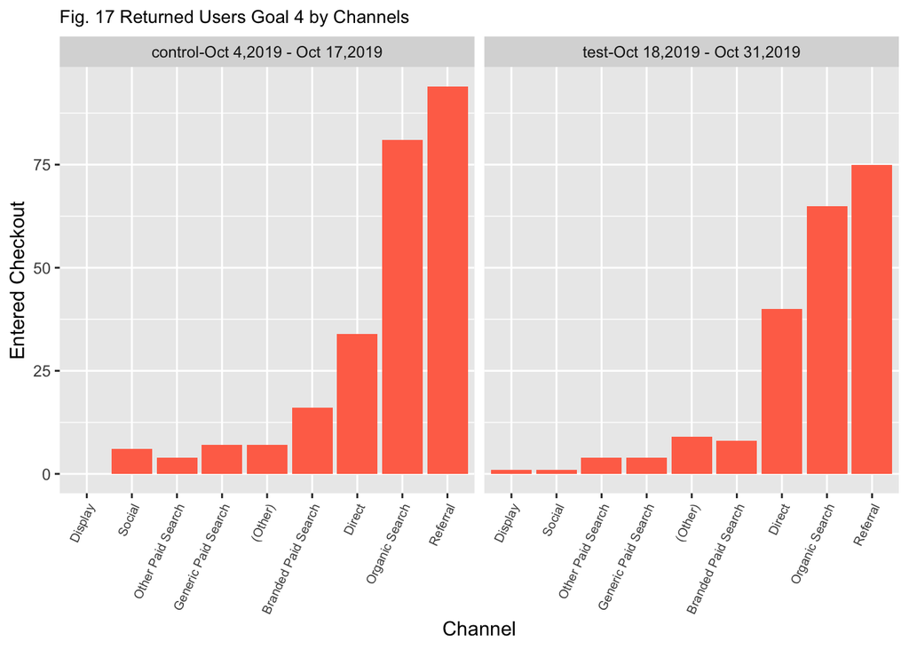

```r
DC_03 %>%
ggplot(aes(reorder(x=Channel, Entered_checkout), y=Entered_checkout)) +
  geom_bar(stat="identity",fill = "coral1")  + theme(plot.title = element_text(size =10),axis.text.x = element_text(size =7,angle = 65, hjust = 1) ) + ggtitle("Fig. 17 Returned Users Goal 4 by Channels ") +xlab("Channel") + ylab("Entered Checkout") + facet_wrap(~test_categ)
```

Import Data Channel- Returning Users - Goal5 - Smart Goals

```r
DA_Goal5 <-  read_excel("~/Desktop/Job related/Surefoot/Surefoot 2/Surefoot- GA/Analysis - 2/test and control dates/Returned Users+Channel/Channel+Goal5.xlsx", sheet = 2)
```

Data wrangling

```r
DC_01 <- DA_Goal5

colnames(DC_01)[colnames(DC_01)=="Smart Goals (Goal 5 Completions)"] <- "Smart_Goals"
colnames(DC_01)[colnames(DC_01)=="Default Channel Grouping"] <- "Channel"
colnames(DC_01)[colnames(DC_01)=="Date Range"] <- "Date_Range"
colnames(DC_01)[colnames(DC_01)=="New Users"] <- "New_Users"
colnames(DC_01)[colnames(DC_01)=="Bounce Rate"] <- "Bounce_Rate"


DC_02 <- DC_01 %>% filter(!is.na(Channel))

DC_03 <- DC_02 %>% mutate(test_categ = ifelse(Date_Range == "Oct 18, 2019 - Oct 31, 2019", "test-Oct 18,2019 - Oct 31,2019", "control-Oct 4,2019 - Oct 17,2019"))

DG5_m <- DC_03 %>% filter(Date_Range == "Oct 18, 2019 - Oct 31, 2019")
```

Visualizations

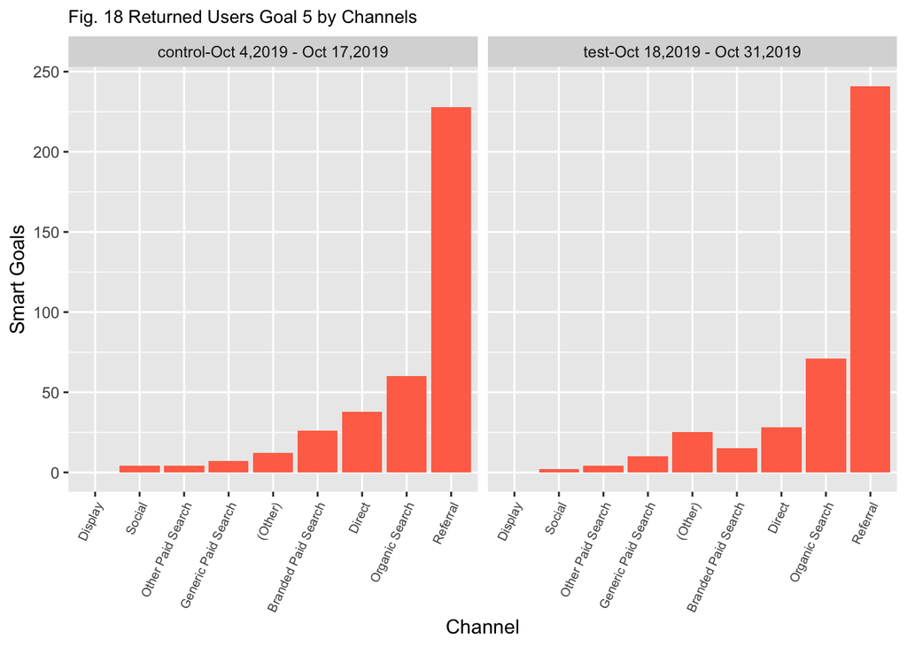

```r
DC_03 %>%
ggplot(aes(reorder(x=Channel, Smart_Goals), y=Smart_Goals)) +
  geom_bar(stat="identity",fill = "coral1")  + theme(plot.title = element_text(size =10),axis.text.x = element_text(size =7,angle = 65, hjust = 1) ) + ggtitle("Fig. 18 Returned Users Goal 5 by Channels ") +xlab("Channel") + ylab("Smart Goals") +  facet_wrap(~test_categ)
```

Linear Regression

```r
colnames(DAge_m)[colnames(DAge_m)=="Pages / Session"] <- "Page_Session"
colnames(DAge_m)[colnames(DAge_m)=="Avg. Session Duration"] <- "Avg_Session_Duration"
colnames(DAge_m)[colnames(DAge_m)=="Ecommerce Conversion Rate"] <- "E_Conversion_Rate"

colnames(DG_m)[colnames(DG_m)=="Pages / Session"] <- "Page_Session"
colnames(DG_m)[colnames(DG_m)=="Avg. Session Duration"] <- "Avg_Session_Duration"
colnames(DG_m)[colnames(DG_m)=="Ecommerce Conversion Rate"] <- "E_Conversion_Rate"


colnames(DG1_m)[colnames(DG1_m)=="Pages / Session"] <- "Page_Session"
colnames(DG1_m)[colnames(DG1_m)=="Avg. Session Duration"] <- "Avg_Session_Duration"
colnames(DG1_m)[colnames(DG1_m)=="Ecommerce Conversion Rate"] <- "E_Conversion_Rate"

colnames(DG2_m)[colnames(DG2_m)=="Pages / Session"] <- "Page_Session"
colnames(DG2_m)[colnames(DG2_m)=="Avg. Session Duration"] <- "Avg_Session_Duration"
colnames(DG2_m)[colnames(DG2_m)=="Ecommerce Conversion Rate"] <- "E_Conversion_Rate"

model_01x <- lm(Revenue ~ Channel+Age+Users+Bounce_Rate+Transactions+Page_Session +E_Conversion_Rate , data = DAge_m)
summary(model_01x)
```

```
##
## Call:
## lm(formula = Revenue ~ Channel + Age + Users + Bounce_Rate +
##     Transactions + Page_Session + E_Conversion_Rate, data = DAge_m)
##
## Residuals:
##      Min       1Q   Median       3Q      Max
## -0.11627 -0.02229  0.00000  0.01759  0.17287
##
## Coefficients:
##                              Estimate Std. Error  t value Pr(>|t|)
## (Intercept)                 6.925e-02  2.645e-01    0.262   0.7993
## ChannelBranded Paid Search -8.630e-02  1.220e-01   -0.708   0.4971
## ChannelDirect               3.013e-03  9.112e-02    0.033   0.9743
## ChannelGeneric Paid Search -7.110e-02  1.124e-01   -0.632   0.5429
## ChannelOrganic Search       2.815e-01  1.706e-01    1.650   0.1334
## ChannelOther Paid Search   -4.834e-02  1.113e-01   -0.434   0.6744
## ChannelReferral             1.523e-01  1.149e-01    1.326   0.2176
## ChannelSocial               5.046e-03  1.261e-01    0.040   0.9690
## Age25-34                    2.395e-02  6.962e-02    0.344   0.7387
## Age35-44                   -1.140e-02  7.017e-02   -0.162   0.8745
## Age45-54                   -1.737e-01  1.183e-01   -1.468   0.1762
## Age55-64                   -3.368e-01  2.044e-01   -1.648   0.1338
## Age65+                     -2.664e-01  1.670e-01   -1.595   0.1453
## Users                      -1.149e-03  4.541e-04   -2.530   0.0322 *
## Bounce_Rate                -1.959e-01  5.012e-01   -0.391   0.7051
## Transactions                6.976e+01  1.834e-01  380.407   <2e-16 ***
## Page_Session                1.600e-02  2.849e-02    0.562   0.5880
## E_Conversion_Rate          -8.567e+03  5.347e+01 -160.222   <2e-16 ***
## ---
## Signif. codes:  0 '***' 0.001 '**' 0.01 '*' 0.05 '.' 0.1 ' ' 1
##
## Residual standard error: 0.09892 on 9 degrees of freedom
## Multiple R-squared:      1,  Adjusted R-squared:      1
## F-statistic: 6.728e+04 on 17 and 9 DF,  p-value: < 2.2e-16
```

```r
model_02x <- lm(Revenue ~ Channel+ Gender +Users+Bounce_Rate+Transactions+Page_Session   , data = DG_m)
summary(model_02x)
```

```
##
## Call:
## lm(formula = Revenue ~ Channel + Gender + Users + Bounce_Rate +
##     Transactions + Page_Session, data = DG_m)
##
## Residuals:
##          1          2          3          4          5          6
##  3.902e+00 -3.996e+00 -3.902e+00  3.996e+00 -5.662e+00  5.662e+00
##          7          8          9         10         11         12
##  1.505e+00 -1.505e+00  1.939e+00 -1.939e+00 -2.237e+00  1.760e+00
##         13         14         15         16         17
##  2.790e+00 -1.760e+00  2.237e+00  6.661e-16 -2.790e+00
##
## Coefficients:
##                             Estimate Std. Error t value Pr(>|t|)
## (Intercept)                 62.03067   47.62935   1.302   0.2838
## ChannelBranded Paid Search  11.86590   11.08561   1.070   0.3629
## ChannelDirect                2.25551   12.26021   0.184   0.8658
## ChannelDisplay              26.83557   16.75995   1.601   0.2077
## ChannelGeneric Paid Search  15.99160   15.32986   1.043   0.3735
## ChannelOrganic Search       -9.60326   26.32780  -0.365   0.7395
## ChannelOther Paid Search    -3.07282    9.78906  -0.314   0.7742
## ChannelReferral             -7.78370   24.17229  -0.322   0.7686
## ChannelSocial               -3.75402   13.67308  -0.275   0.8015
## Gendermale                   1.46401    8.64886   0.169   0.8764
## Users                        0.07901    0.03481   2.270   0.1079
## Bounce_Rate                -45.42725   37.07770  -1.225   0.3079
## Transactions                27.02130    9.43952   2.863   0.0644 .
## Page_Session               -12.54020    9.09500  -1.379   0.2618
## ---
## Signif. codes:  0 '***' 0.001 '**' 0.01 '*' 0.05 '.' 0.1 ' ' 1
##
## Residual standard error: 7.535 on 3 degrees of freedom
## Multiple R-squared:  0.9864, Adjusted R-squared:  0.9275
## F-statistic: 16.74 on 13 and 3 DF,  p-value: 0.01997
```

```r
DD_m_01 <- DD_m %>% filter(Device != "tablet")
model_03x <- lm(Revenue ~ Channel+Device+Users +Bounce_Rate+Transactions  , data = DD_m_01)
summary(model_03x)
```

```
##
## Call:
## lm(formula = Revenue ~ Channel + Device + Users + Bounce_Rate +
##     Transactions, data = DD_m_01)
##
## Residuals:
##        1        2        3        4        5        6        7        8
## -16.9576  14.4340  16.9576   4.0571   3.5810  -4.0571  -6.8365  -0.8082
##        9       10       11       12       13       14       15       16
##  -1.6324   6.8365  -2.0501  -3.5810   2.0501   1.6324  -6.2128 -14.4340
##       17       18
##   0.8082   6.2128
##
## Coefficients:
##                             Estimate Std. Error t value Pr(>|t|)
## (Intercept)                 22.12923   28.19155   0.785   0.4680
## ChannelBranded Paid Search -11.11984   17.05302  -0.652   0.5431
## ChannelDirect                2.01540   19.17383   0.105   0.9204
## ChannelDisplay              10.88584   24.78688   0.439   0.6789
## ChannelGeneric Paid Search  -5.31890   16.66987  -0.319   0.7626
## ChannelOrganic Search      123.22305   40.02435   3.079   0.0275 *
## ChannelOther Paid Search    -8.86252   18.16109  -0.488   0.6462
## ChannelReferral             15.51671   17.95941   0.864   0.4271
## ChannelSocial                5.95246   19.41472   0.307   0.7715
## Devicemobile                 2.62866   10.09208   0.260   0.8049
## Users                       -0.02470    0.01383  -1.786   0.1341
## Bounce_Rate                -45.80169   62.15216  -0.737   0.4943
## Transactions                23.68784    7.31855   3.237   0.0230 *
## ---
## Signif. codes:  0 '***' 0.001 '**' 0.01 '*' 0.05 '.' 0.1 ' ' 1
##
## Residual standard error: 15.72 on 5 degrees of freedom
## Multiple R-squared:  0.9824, Adjusted R-squared:  0.9402
## F-statistic: 23.28 on 12 and 5 DF,  p-value: 0.001355
```

```r
model_04x <- lm(Revenue ~ Channel+Hour+ Users +Bounce_Rate+Transactions   , data = DH_m)
summary(model_04x)
```

```
##
## Call:
## lm(formula = Revenue ~ Channel + Hour + Users + Bounce_Rate +
##     Transactions, data = DH_m)
##
## Residuals:
##      Min       1Q   Median       3Q      Max
## -23.0573  -0.6623   0.0508   1.2726  27.3992
##
## Coefficients:
##                             Estimate Std. Error t value Pr(>|t|)
## (Intercept)                 0.192763   2.083830   0.093    0.926
## ChannelBranded Paid Search -1.012046   1.437673  -0.704    0.482
## ChannelDirect              -2.294941   1.557823  -1.473    0.142
## ChannelDisplay              0.261170   1.504262   0.174    0.862
## ChannelGeneric Paid Search -0.486882   1.447895  -0.336    0.737
## ChannelOrganic Search       1.723665   3.511277   0.491    0.624
## ChannelOther Paid Search    0.015908   1.484524   0.011    0.991
## ChannelReferral            -0.773230   2.108862  -0.367    0.714
## ChannelSocial               0.176731   1.455879   0.121    0.904
## Hour01                     -1.137774   2.351763  -0.484    0.629
## Hour02                     -0.043247   2.320910  -0.019    0.985
## Hour03                     -0.080128   2.325466  -0.034    0.973
## Hour04                     -1.493578   2.330774  -0.641    0.522
## Hour05                     -0.028415   2.320073  -0.012    0.990
## Hour06                     -0.115870   2.330601  -0.050    0.960
## Hour07                     -0.177353   2.351891  -0.075    0.940
## Hour08                      2.210848   2.374835   0.931    0.353
## Hour09                     -2.320108   2.351060  -0.987    0.325
## Hour10                     -0.224516   2.370333  -0.095    0.925
## Hour11                      0.533568   2.437679   0.219    0.827
## Hour12                     -0.193637   2.361003  -0.082    0.935
## Hour13                     -0.298061   2.381506  -0.125    0.901
## Hour14                      0.409210   2.371655   0.173    0.863
## Hour15                      0.365861   2.344767   0.156    0.876
## Hour16                     -2.800317   2.332778  -1.200    0.232
## Hour17                     -0.107845   2.328024  -0.046    0.963
## Hour18                      2.719848   2.329307   1.168    0.244
## Hour19                     -0.032991   2.320319  -0.014    0.989
## Hour20                     -2.267156   2.343582  -0.967    0.335
## Hour21                      2.132393   2.360323   0.903    0.367
## Hour22                     -1.150913   2.343345  -0.491    0.624
## Hour23                      0.004562   2.337482   0.002    0.998
## Users                       0.008665   0.019150   0.453    0.651
## Bounce_Rate                -0.466426   1.716171  -0.272    0.786
## Transactions               35.163701   1.345922  26.126   <2e-16 ***
## ---
## Signif. codes:  0 '***' 0.001 '**' 0.01 '*' 0.05 '.' 0.1 ' ' 1
##
## Residual standard error: 4.92 on 181 degrees of freedom
## Multiple R-squared:  0.8553, Adjusted R-squared:  0.8281
## F-statistic: 31.46 on 34 and 181 DF,  p-value: < 2.2e-16
```

```r
c<- data.frame(summary(model_04x)$coef[summary(model_04x)$coef[,4] <= .05, 4])
colnames(c) <- c("p-value")
c
```

```
##       p-value
## 1 2.55716e-63
```

```r
model_06x <- lm(Revenue ~ Channel+ City+Users +Bounce_Rate+Transactions   , data = DC_m)
#summary(model_06x)
d<- data.frame(summary(model_06x)$coef[summary(model_06x)$coef[,4] <= .05, 4])
colnames(d) <- c("p-value")
d
```

```
##                                 p-value
## ChannelBranded Paid Search 2.845424e-02
## CityAlbany                 8.602910e-04
## CityFarmers Branch         1.400944e-29
## CityHonolulu               3.577416e-05
## CityLong Beach             2.198061e-16
## CityLos Banos              2.387069e-05
## CityNew York               3.623952e-02
## CityRiverview              1.965077e-03
## CitySyracuse               1.759470e-37
## Transactions               0.000000e+00
```

```r
model_07x <- lm(Revenue ~ Channel+ Country+  Users+Sessions+Bounce_Rate+Transactions   , data = DCo_m)
#summary(model_07x)
e<- data.frame(summary(model_07x)$coef[summary(model_07x)$coef[,4] <= .05, 4])
colnames(e) <- c("p-value")
e
```

```
##                                  p-value
## ChannelBranded Paid Search  2.556892e-02
## ChannelGeneric Paid Search  3.735041e-03
## CountryBelgium              2.683823e-02
## CountryUnited Kingdom       5.638469e-03
## CountryUnited States        2.570708e-07
## Users                       6.550561e-30
## Sessions                    2.618611e-28
## Transactions               2.257148e-179
```

```r
model_08x <- lm( Pageviews ~    Channel+ Bounce_Rate+Entrances+Page   , data = DP_m)
#summary(model_08x)
a<- data.frame(summary(model_08x)$coef[summary(model_08x)$coef[,4] <= .05, 4])
colnames(a) <- c("p-value")
 a
```

[output not shown]

[output cut: 463 more lines]

```r
model_10x <- lm( Revenue ~  Ad_Content+Users   , data = DAd_m)
summary(model_10x)
```

```
##
## Call:
## lm(formula = Revenue ~ Ad_Content + Users, data = DAd_m)
##
## Residuals:
##     Min      1Q  Median      3Q     Max
## -172.39    0.00    0.00   11.59   88.20
##
## Coefficients:
##                                           Estimate Std. Error t value
## (Intercept)                              -26.92532   28.16828  -0.956
## Ad_ContentAndroid Merchandise Collection  26.92532   69.41026   0.388
## Ad_ContentGoogle Merchandise Collection   22.85285   52.72959   0.433
## Ad_ContentGoogle Merchandise Store        25.54786   52.88633   0.483
## Ad_ContentGoogle Office Merchandise       26.92532   69.41026   0.388
## Ad_ContentOfficial Google Branded Bags    26.50609   52.94309   0.501
## Ad_ContentOfficial Google Drinkware       26.20664   69.37761   0.378
## Ad_ContentOfficial Google Men's Apparel   26.80554   69.40481   0.386
## Ad_ContentOfficial Google Merchandis      26.92532   69.41026   0.388
## Ad_ContentOfficial Google Merchandise     28.44778   52.14600   0.546
## Ad_ContentOfficial YouTube Merchandise    26.80554   69.40481   0.386
## Ad_ContentYouTube                         26.92532   69.41026   0.388
## Ad_ContentYouTube Accessories Collection  26.92532   69.41026   0.388
## Ad_ContentYouTube Merchandise Collection  26.80554   69.40481   0.386
## Users                                      0.11978    0.02225   5.384
##                                          Pr(>|t|)
## (Intercept)                              0.361673
## Ad_ContentAndroid Merchandise Collection 0.706208
## Ad_ContentGoogle Merchandise Collection  0.673926
## Ad_ContentGoogle Merchandise Store       0.639447
## Ad_ContentGoogle Office Merchandise      0.706208
## Ad_ContentOfficial Google Branded Bags   0.627450
## Ad_ContentOfficial Google Drinkware      0.713518
## Ad_ContentOfficial Google Men's Apparel  0.707424
## Ad_ContentOfficial Google Merchandis     0.706208
## Ad_ContentOfficial Google Merchandise    0.597339
## Ad_ContentOfficial YouTube Merchandise   0.707424
## Ad_ContentYouTube                        0.706208
## Ad_ContentYouTube Accessories Collection 0.706208
## Ad_ContentYouTube Merchandise Collection 0.707424
## Users                                    0.000308 ***
## ---
## Signif. codes:  0 '***' 0.001 '**' 0.01 '*' 0.05 '.' 0.1 ' ' 1
##
## Residual standard error: 63.44 on 10 degrees of freedom
## Multiple R-squared:  0.775,  Adjusted R-squared:  0.4601
## F-statistic: 2.461 on 14 and 10 DF,  p-value: 0.07846
```

```r
model_11x <- lm( Purchases_completed ~  Users    , data = DG1_m)
summary(model_11x)
```

```
##
## Call:
## lm(formula = Purchases_completed ~ Users, data = DG1_m)
##
## Residuals:
##     Min      1Q  Median      3Q     Max
## -3.5707 -0.2076  0.0367  0.7725  1.9744
##
## Coefficients:
##               Estimate Std. Error t value Pr(>|t|)
## (Intercept) -0.1559898  0.7149738  -0.218  0.83352
## Users        0.0028405  0.0005975   4.754  0.00207 **
## ---
## Signif. codes:  0 '***' 0.001 '**' 0.01 '*' 0.05 '.' 0.1 ' ' 1
##
## Residual standard error: 1.713 on 7 degrees of freedom
## Multiple R-squared:  0.7635, Adjusted R-squared:  0.7297
## F-statistic:  22.6 on 1 and 7 DF,  p-value: 0.002074
```

```r
model_12x <- lm( Engaged_Users ~  Users   , data = DG2_m)
summary(model_12x)
```

```
##
## Call:
## lm(formula = Engaged_Users ~ Users, data = DG2_m)
##
## Residuals:
##     Min      1Q  Median      3Q     Max
## -61.264 -15.673  -8.665   4.311 117.741
##
## Coefficients:
##             Estimate Std. Error t value Pr(>|t|)
## (Intercept)  4.33137   21.55488   0.201    0.846
## Users        0.15080    0.01801   8.371 6.82e-05 ***
## ---
## Signif. codes:  0 '***' 0.001 '**' 0.01 '*' 0.05 '.' 0.1 ' ' 1
##
## Residual standard error: 51.65 on 7 degrees of freedom
## Multiple R-squared:  0.9092, Adjusted R-squared:  0.8962
## F-statistic: 70.08 on 1 and 7 DF,  p-value: 6.815e-05
```

```r
model_13x <- lm( Registrations_completed ~  Users   , data = DG3_m)
summary(model_13x)
```

```
##
## Call:
## lm(formula = Registrations_completed ~ Users, data = DG3_m)
##
## Residuals:
##     Min      1Q  Median      3Q     Max
## -6.8195 -1.2120  0.1657  2.3889  4.2781
##
## Coefficients:
##             Estimate Std. Error t value Pr(>|t|)
## (Intercept) 1.066793   1.427871   0.747   0.4793
## Users       0.003457   0.001193   2.897   0.0231 *
## ---
## Signif. codes:  0 '***' 0.001 '**' 0.01 '*' 0.05 '.' 0.1 ' ' 1
##
## Residual standard error: 3.422 on 7 degrees of freedom
## Multiple R-squared:  0.5453, Adjusted R-squared:  0.4803
## F-statistic: 8.393 on 1 and 7 DF,  p-value: 0.02308
```

```r
model_14x <- lm( Entered_checkout ~  Users   , data = DG4_m)
summary(model_14x)
```

```
##
## Call:
## lm(formula = Entered_checkout ~ Users, data = DG4_m)
##
## Residuals:
##     Min      1Q  Median      3Q     Max
## -17.779  -4.639  -3.995  -2.227  27.779
##
## Coefficients:
##             Estimate Std. Error t value Pr(>|t|)
## (Intercept) 4.531387   6.019582   0.753   0.4761
## Users       0.025655   0.005031   5.100   0.0014 **
## ---
## Signif. codes:  0 '***' 0.001 '**' 0.01 '*' 0.05 '.' 0.1 ' ' 1
##
## Residual standard error: 14.42 on 7 degrees of freedom
## Multiple R-squared:  0.7879, Adjusted R-squared:  0.7576
## F-statistic: 26.01 on 1 and 7 DF,  p-value: 0.0014
```

```r
model_15x <- lm(Smart_Goals ~  Users    , data = DG5_m)
summary(model_15x)
```

```
##
## Call:
## lm(formula = Smart_Goals ~ Users, data = DG5_m)
##
## Residuals:
##     Min      1Q  Median      3Q     Max
## -77.376 -14.904 -13.487  -6.697 154.709
##
## Coefficients:
##             Estimate Std. Error t value Pr(>|t|)
## (Intercept) 11.75293   27.75000   0.424   0.6846
## Users        0.04479    0.02319   1.932   0.0947 .
## ---
## Signif. codes:  0 '***' 0.001 '**' 0.01 '*' 0.05 '.' 0.1 ' ' 1
##
## Residual standard error: 66.5 on 7 degrees of freedom
## Multiple R-squared:  0.3477, Adjusted R-squared:  0.2545
## F-statistic: 3.731 on 1 and 7 DF,  p-value: 0.09471
```